# Sobol Sensitivity Analysis of Atmospheric Conductance Model

Comparision of Two Scenarios

Author

Jaden Orli

Published

May 11, 2025

# I. Background

This document employs Sobol indices to explore a variance-based sensitivity analysis on two scenarios simulated with a model of atmospheric conductance.

## a) Sobol Indices

Sobol sequences are a quasi-random sampling technique that is designed to *uniformly* fill the multi-dimensional parameter space. This is achieved by sampling from the unit cube $[0,1]^d$ and then using a quantile transformation to map these values onto the real distributions (Saltelli and Annoni 2010). The Sobol method requires working in this normalized space ([0,1]) to compute the first-order sensitivity, total sensitivity, and interaction effects by decomposing the total output variance into the corresponding contributions from each input. This sensitivity analysis technique is preferred when working with nonlinear models since it evenly explores all parts of the parameter space while avoiding clumping or gaps that can be associated with random sampling.

## b) Atmospheric Conductance Model

For this analysis we will use a model developed to calculate atmospheric conductance based on windspeed and vegetation height. The general form of this equation is outlined below:

## c) Multi-Dimensional Parameter Space

Since there are four uncertain parameters, we have a four-dimensional parameter space where a single sample lies within the unit hypercube $(v, h, k_d, k_o) \in [0,1]^4$. These are unit-uniform samples that must then be transformed to match the real distributions. It is fundamental that these parameters are sampled from a uniform space, however, these values only become meaningful when mapped to the true distributions by inverting their cumulative distribution functions (Saltelli and Annoni 2010).

# II. Set Up

First, we will load the necessary libraries for this workflow.

## a) Load Libraries

```r
#this clears out the environment
rm(list = ls())

#load the necessary libraries
library(calecopal)
library(sensitivity)
library(tidyverse)
#library(gridExtra)
library(purrr)
#library(ggpubr)
library(here)
library(kableExtra)
library(htmltools)
library(janitor)
```

## b) Sobol Design

Then, to start, we will generate two samples of parameters sets by sampling from apriori distributions for each parameter value.

```r
#set the seed for reproducibility
set.seed(42)

#determine the number of parameter values to simulate for each parameter metric
np <- 1000

#create a color palette to use throughout the project
superbloom1 <- cal_palette(name = "superbloom1", n = 50, type = "continuous")

#create a named list of colors from the superbloom1 palette
colors <- c(uniform = "#8A7E9B",
            simu1 = "#646A2D",
            simu2 = "#437C90")
```

### i) Unit-Uniform Distriubtions

As previously disccused, the first step in this process is to generate inputs (unit samples) with a uniform distribution across the four-dimensional parameter space. Eventually these samples will be transformed back to their true distributions after the Sobol sequences are selected. This method of Sobol analysis allows us to construct a structured set of inputs that can be evaluated to determine how sensitive the model output is to each of the four input parameters.

```r
#use the sobolSalt function to create a structured set of inputs
sobol_obj <- sobolSalt(model = NULL,
                       X1 = matrix(runif(np * 4), nrow = np), #generate unit-uniform samples in [0,1] for X1
                       X2 = matrix(runif(np * 4), nrow = np), #generate unit-uniform samples in [0,1] for X2
                       nboot = 100, #use 100 bootstrap replications
                       scheme = "B") #allows for second-order interactions
```

### ii) Extract Raw Sample Matrix

We can evaluate the distributions of these unit-uniform samples by extracting the raw Sobol sample matrix.

```r
#extract the raw Sobol sample matrix (in [0, 1])
X_raw <- as.data.frame(sobol_obj$X)

#name the columns in the dataframe
colnames(X_raw) <- c("v_raw", "h_raw", "kd_raw", "ko_raw")
```

### iii) Visualize Uniform Distributions

And then we can visualize these distributions to ensure that they are uniform and normalized.

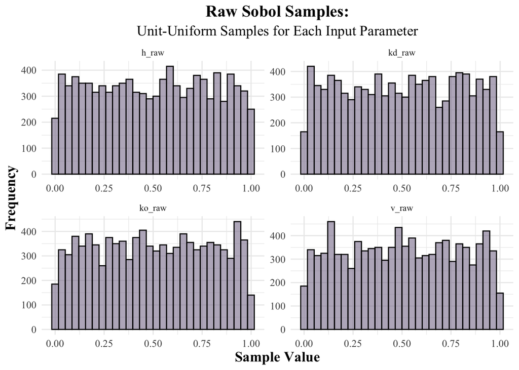

```r
#pivot the raw samples to a longer format
X_long <- X_raw %>% #start with X_raw
  pivot_longer(cols = everything(), #select the values from all four columns
               names_to = "Parameter", #create a new column called parameter with the old column headers
               values_to = "Value") #create a new column called value with the corresponding values

#plot histograms for each of the parameters
ggplot(X_long, aes(x = Value)) +
  geom_histogram(bins = 30, fill = colors["uniform"], color = "black", alpha = 0.6) +
  facet_wrap(~Parameter, scales = "free") +
  labs(title = "Raw Sobol Samples:",
       subtitle = "Unit-Uniform Samples for Each Input Parameter",
       x = "Sample Value",
       y = "Frequency") +
  theme_minimal() +
  theme(text = element_text(family = "Times New Roman"),
        plot.title = element_text(face = "bold", size = 16, hjust = 0.5),
        plot.subtitle = element_text(size = 14, hjust = 0.5),
        axis.title = element_text(face = "bold", size = 14),
        axis.text = element_text(size = 10))
```

## c) Transform Sobol Samples

After establishing a uniform distribution for each of the sample parameter values, we can explore two scenarios of parameter values.

### i) Compare Scenarios

The parameters for windspeed ($v$) and vegetation height ($h$) will vary in either scenario. However, in both scenarios we will transform the below parameters using the outlined assumptions:

$$
$$\begin{align}
k_d &\quad \text{= normally distributed with a mean of 0.7 and a standard deviation of 0.007} \\
k_o &\quad \text{= normally distributed with a mean of 0.1 and a standard deviation of 0.001}
\end{align}$$
$$

In scenario one, the below windspeed and vegetation height are used to simulate an area with short vegetation and fast, highly variable windspeeds:

$$
$$\begin{align}
v &\quad \text{= normally distributed with a mean of 300 cm/s and a standard deviation of 50cm/s} \\
h &\quad \text{= equally likely across a range of 3.5m and 5.5m} \\
\end{align}$$
$$ In scenario two, the environment is simulated to have lower, less variable windspeeds and taller vegetation following the below distributions:

$$
$$\begin{align}
v &\quad \text{= normally distributed with a mean of 250 cm/s and a standard deviation of 30cm/s} \\
h &\quad \text{= equally likely across a range of 9.5m and 10.5m} \\
\end{align}$$
$$

### ii) Transform Distributions

Now we can transform the samples according to the true distributions defined for each scenario.

```r
#transform the samples according to the true distributions
X_transformed1 <- data.frame(v = qnorm(X_raw$v_raw, mean = 3.00, sd = 0.50), #use a quantile normal distribution
                             h = qunif(X_raw$h_raw, min = 3.5, max = 5.5), #use a quantile uniform distribution
                             kd = qnorm(X_raw$kd_raw, mean = 0.7, sd = 0.007), #use a quantile normal distribution
                             ko = qnorm(X_raw$ko_raw, mean = 0.1, sd = 0.001)) #use a quantile normal distribution

#create a list of parameter names
param_names <- colnames(X_transformed1)

#transform the samples according to the true distributions
X_transformed2 <- data.frame(v = qnorm(X_raw$v_raw, mean = 2.50, sd = 0.30), #use a quantile normal distribution
                             h = qunif(X_raw$h_raw, min = 9.5, max = 10.5), #use a quantile uniform distribution
                             kd = qnorm(X_raw$kd_raw, mean = 0.7, sd = 0.007), #use a quantile normal distribution
                             ko = qnorm(X_raw$ko_raw, mean = 0.1, sd = 0.001)) #use a quantile normal distribution
```

### iii) Evaluate Scenarios

After using the quantile transformations, we can visualize the distribution of parameter sample values to ensure they follow their true distribution.

```r
#pivot the transformed samples to a longer format
X_trans_long1 <- X_transformed1 %>%
  pivot_longer(cols = everything(), #select the values from all four columns
               names_to = "Parameter", #create a new column called parameter with the old column headers
               values_to = "Value") #create a new column called value with the corresponding values

#pivot the transformed samples to a longer format
X_trans_long2 <- X_transformed2 %>%
  pivot_longer(cols = everything(), #select the values from all four columns
               names_to = "Parameter", #create a new column called parameter with the old column headers
               values_to = "Value") #create a new column called value with the corresponding values
```

#### 1. Scenario One

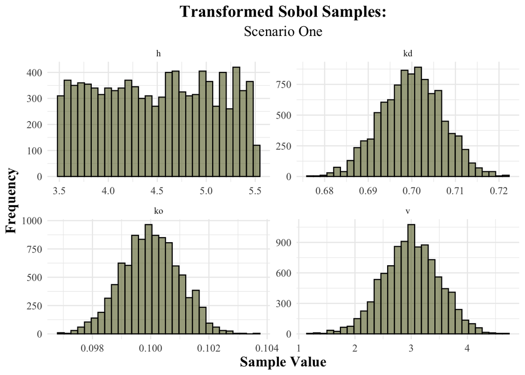

```r
#plot histograms for each of the parameters
ggplot(X_trans_long1, aes(x = Value)) +
  geom_histogram(bins = 30, fill = colors["simu1"], color = "black", alpha = 0.6) +
  facet_wrap(~Parameter, scales = "free") +
  labs(title = "Transformed Sobol Samples:",
       subtitle = "Scenario One",
       x = "Sample Value",
       y = "Frequency") +
  theme_minimal() +
  theme(text = element_text(family = "Times New Roman"),
        plot.title = element_text(face = "bold", size = 16, hjust = 0.5),
        plot.subtitle = element_text(size = 14, hjust = 0.5),
        axis.title = element_text(face = "bold", size = 14),
        axis.text = element_text(size = 10))
```

#### 2. Scenario Two

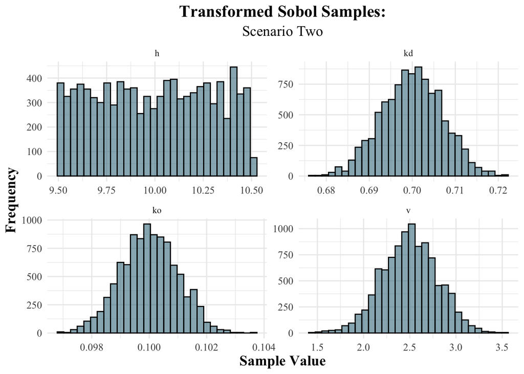

```r
#plot histograms for each of the parameters
ggplot(X_trans_long2, aes(x = Value)) +
  geom_histogram(bins = 30, fill = colors["simu2"], color = "black", alpha = 0.6) +
  facet_wrap(~Parameter, scales = "free") +
  labs(title = "Transformed Sobol Samples:",
       subtitle = "Scenario Two",
       x = "Sample Value",
       y = "Frequency") +
  theme_minimal() +
  theme(text = element_text(family = "Times New Roman"),
        plot.title = element_text(face = "bold", size = 16, hjust = 0.5),
        plot.subtitle = element_text(size = 14, hjust = 0.5),
        axis.title = element_text(face = "bold", size = 14),
        axis.text = element_text(size = 10))
```

Now that we have verified that each set of parameter sample values follows the appropriate distribution, we can apply the atmospheric model for these parameters sets for both scenarios.

# III. Atmospheric Conductance Model

First, we can examine the script containing the appropriate function and ensure that the parameters align with those we have sampled.

## a) Atmospheric Conductance Function

```r
#load in the atmospheric_conductance function
source(here("scripts", "atm_conductance.R"))

#view the format of the function
atmospheric_condunctance
```

```
function (v, h, zm_add = 2, ko, kd)
{
    zd <- kd * h
    zo <- ko * h
    zm <- h + zm_add
    zd <- ifelse(zd < 0, 0, zd)
    Ca <- ifelse(zo > 0, v/(6.25 * log((zm - zd)/zo)^2), 0)
    Ca <- Ca * 1000
    return(Ca)
}
```

## b) Compute Atmospheric Conductance

Then we can use the atmospheric_conductance to calculate the conductance in mm/s for each set of simulated parameter values.

```r
#use the atmospheric_conductance function to calculate the atmospheric conductance for each set of parameters generated using the Sobol method
X_transformed1$Ca <- pmap_dbl(X_transformed1, atmospheric_condunctance) #map the atmospheric_conductance function over the columns of the X_transformed df
```

```r
#use the atmospheric_conductance function to calculate the atmospheric conductance for each set of parameters generated using the Sobol method
X_transformed2$Ca <- pmap_dbl(X_transformed2, atmospheric_condunctance) #map the atmospheric_conductance function over the columns of the X_transformed df
```

## c) Visualize Conductance Estimates

Next, we can visualize the distribution of atmospheric conductance estimates across both simulations to help us further evaluate the parameter uncertainty.

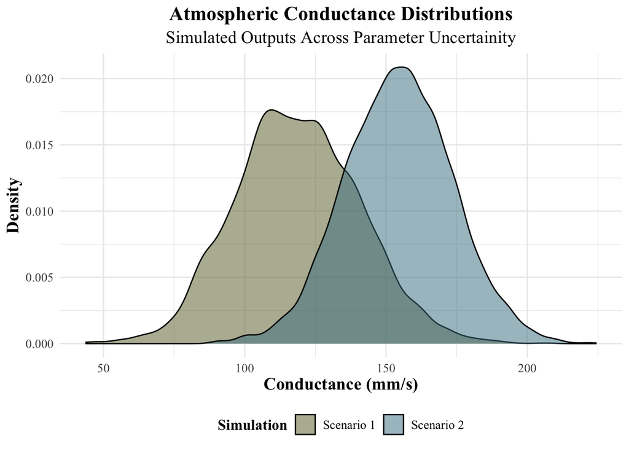

```r
# Combine both simulations into one dataframe with a label
X_combined <- bind_rows(X_transformed1 %>% mutate(simulation = "Scenario 1"),
                        X_transformed2 %>% mutate(simulation = "Scenario 2"))

ggplot(X_combined, aes(x = Ca, fill = simulation)) +
  geom_density(alpha = 0.5, color = "black") +
  scale_fill_manual(values = c("Scenario 1" = colors[["simu1"]],
                               "Scenario 2" = colors[["simu2"]])) +
  labs(title = "Atmospheric Conductance Distributions",
       subtitle = "Simulated Outputs Across Parameter Uncertainity",
       x = "Conductance (mm/s)",
       y = "Density",
       fill = "Simulation") +
  theme_minimal() +
  theme(text = element_text(family = "Times New Roman"),
        plot.title = element_text(face = "bold", size = 16, hjust = 0.5),
        plot.subtitle = element_text(size = 14, hjust = 0.5),
        axis.title = element_text(face = "bold", size = 14),
        axis.text = element_text(size = 10),
        legend.title = element_text(face = "bold", size = 12),
        legend.text = element_text(size = 10),
        legend.position = "bottom")
```

# IV. Sobol Indicies

Finally, we can calculate the total-effect and first-order Sobol indices to determine the parameter sensitivities for both simulations.

## a) Calculate Indicies

```r
#update the matrix of the Sobol object to contain a full matrix of parameter sets
sobol_parms1 <- sensitivity::tell(sobol_obj, #method to estimate the sensitivity measures of the incomplete Sobol object
                                 X_transformed1$Ca) #estimated using the conductance values output from the model

#assign the correct column names/parameters to the Sobol object for the total-effect Sobol index matrix
rownames(sobol_parms1$T) <- colnames(X_transformed1)[1:4]

#assign the correct column names/parameters to the Sobol object for the first-order Sobol index matrix
rownames(sobol_parms1$S) <- colnames(X_transformed1)[1:4]
```

```r
#update the matrix of the Sobol object to contain a full matrix of parameter sets
sobol_parms2 <- sensitivity::tell(sobol_obj, #method to estimate the sensitivity measures of the incomplete Sobol object
                                 X_transformed2$Ca) #estimated using the conductance values output from the model

#assign the correct column names/parameters to the Sobol object for the total-effect Sobol index matrix
rownames(sobol_parms2$T) <- colnames(X_transformed2)[1:4]

#assign the correct column names/parameters to the Sobol object for the first-order Sobol index matrix
rownames(sobol_parms2$S) <- colnames(X_transformed2)[1:4]
```

## b) Sobol Indices

### i) Total-Effect Indices

#### 1. Scenario One

```r
#create a dataframe with the total-effect indices
t_indices1 <- sobol_parms1$T %>%
  as.data.frame() %>%
  rownames_to_column(var = "Parameter") %>%
  arrange(desc(original)) %>%  #original holds total-effect index
  clean_names()  %>%
  mutate(influential = case_when(min_c_i <= 0 & max_c_i >= 0 ~ "no", #CI includes zero so the parameter is NOT influential
                                 TRUE ~ "yes")) %>% #CI excludes zero so the parameter is influential
  select(-"std_error", -"bias")

#create a kable
t_kable1 <- kable(t_indices1,
                  col.names = c("Parameter", "Total-Effect Index", "Min C.I.", "Max C.I", "Influential ?"),
                  caption = htmltools::tags$div(style = "text-align: center; font-size: 1rem;",
                                               list(htmltools::tags$strong("Total-Effect Indices"),
                                                    htmltools::tags$br(),
                                                    htmltools::tags$span("Scenario 1: Shorter Vegetation and Higher Windspeed Variability"))),
                  escape = FALSE) %>%
  kable_styling(full_width = FALSE, font_size = "0.8rem", position = "center") %>%
  row_spec(row = 0, bold = TRUE, background = "rgba(174, 209, 200, 0.4)") %>%
  row_spec(row = 0:4, align = "center") %>%
  kable_classic(html_font = "Times New Roman")

#view the kable
t_kable1
```

**Total-Effect Indices** Scenario 1: Shorter Vegetation and Higher Windspeed Variability

| Parameter | Total-Effect Index | Min C.I. | Max C.I | Influential ? |
| --- | --- | --- | --- | --- |
| v | 0.8508528 | 0.7814532 | 0.9198154 | yes |
| h | 0.1931002 | 0.1739132 | 0.2086006 | yes |
| kd | 0.0028905 | 0.0025585 | 0.0032188 | yes |
| ko | 0.0027746 | 0.0024388 | 0.0030295 | yes |

#### 2. Scenario Two

```r
#create a dataframe with the total-effect indices
t_indices2 <- sobol_parms2$T %>%
  as.data.frame() %>%
  rownames_to_column(var = "Parameter") %>%
  arrange(desc(original)) %>%  #original holds total-effect index
  clean_names()  %>%
  mutate(influential = case_when(min_c_i <= 0 & max_c_i >= 0 ~ "no", #CI includes zero so the parameter is NOT influential
                                 TRUE ~ "yes")) %>% #CI excludes zero so the parameter is influential
  select(-"std_error", -"bias")

#create a kable
t_kable2 <- kable(t_indices2,
                  col.names = c("Parameter", "Total-Effect Index", "Min C.I.", "Max C.I", "Influential ?"),
                  caption = htmltools::tags$div(style = "text-align: center; font-size: 1rem;",
                                               list(htmltools::tags$strong("Total-Effect Indices"),
                                                    htmltools::tags$br(),
                                                    htmltools::tags$span("Scenario 2: Taller Vegetation and Lower Windspeed Variability"))),
                  escape = FALSE) %>%
  kable_styling(full_width = FALSE, font_size = "0.8rem", position = "center") %>%
  row_spec(row = 0, bold = TRUE, background = "rgba(174, 209, 200, 0.4)") %>%
  row_spec(row = 0:4, align = "center") %>%
  kable_classic(html_font = "Times New Roman")

#view the kable
t_kable2
```

**Total-Effect Indices** Scenario 2: Taller Vegetation and Lower Windspeed Variability

| Parameter | Total-Effect Index | Min C.I. | Max C.I | Influential ? |
| --- | --- | --- | --- | --- |
| v | 0.9924051 | 0.9047539 | 1.0634922 | yes |
| kd | 0.0209526 | 0.0175957 | 0.0235337 | yes |
| h | 0.0150068 | 0.0131338 | 0.0163682 | yes |
| ko | 0.0095786 | 0.0082495 | 0.0105750 | yes |

Based on the total-effect indices, we can determine that windspeed ($v$) is the most influential parameter in both scenarios. The second most influential parameter in scenario one (shorter vegetation and higher windspeed variability) is vegetation height ($h$) while the second most influential parameter in scenario two (taller vegetation and lower windspeed variability) is the displacement scalar ($k_d$).

### ii) First-Order Indices

The first-order indices indicate the variance associated with the single parameter alone, not including interactions. When a parameter has a high total-effect index and a low first-order index, this indicates that the parameter is mostly important through interactions. When the total-effect and first-order index are roughly equivalent, this means that the parameter acts independently more than interactive. And finally, if the total-effect index is low, this means the parameter is not very influential.

#### 1. Scenario One

```r
#create a dataframe with the first-order indices
s_indices1 <- sobol_parms1$S %>%
  as.data.frame() %>%
  rownames_to_column(var = "Parameter") %>%
  arrange(desc(original)) %>%  #original holds total-effect index
  clean_names()  %>%
  mutate(influential = case_when(min_c_i <= 0 & max_c_i >= 0 ~ "no", #CI includes zero so the parameter is NOT influential
                                 TRUE ~ "yes")) %>% #CI excludes zero so the parameter is influential
  select(-"std_error", - "bias")

#create a kable
s_kable1 <- kable(s_indices1,
                  col.names = c("Parameter", "First-Order Index", "Min C.I.", "Max C.I", "Influential ?"),
                  caption = htmltools::tags$div(style = "text-align: center; font-size: 1rem;",
                                               list(htmltools::tags$strong("First-Order Indices"),
                                                    htmltools::tags$br(),
                                                    htmltools::tags$span("Scenario 1: Shorter Vegetation and Higher Windspeed Variability"))),
                  escape = FALSE) %>%
  kable_styling(full_width = FALSE, font_size = "0.8rem", position = "center") %>%
  row_spec(row = 0, bold = TRUE, background = "rgba(174, 209, 200, 0.4)") %>%
  row_spec(row = 0:4, align = "center") %>%
  kable_classic(html_font = "Times New Roman")

#view the kable
s_kable1
```

**First-Order Indices** Scenario 1: Shorter Vegetation and Higher Windspeed Variability

| Parameter | First-Order Index | Min C.I. | Max C.I | Influential ? |
| --- | --- | --- | --- | --- |
| v | 0.8034752 | 0.7876618 | 0.8231772 | yes |
| h | 0.1417988 | 0.0731275 | 0.2097452 | yes |
| ko | -0.0433952 | -0.1095424 | 0.0363998 | no |
| kd | -0.0442665 | -0.1127062 | 0.0358953 | no |

#### 2. Scenario Two

```r
#create a dataframe with the first-order indices
s_indices2 <- sobol_parms2$S %>%
  as.data.frame() %>%
  rownames_to_column(var = "Parameter") %>%
  arrange(desc(original)) %>%  #original holds total-effect index
  clean_names()  %>%
  mutate(influential = case_when(min_c_i <= 0 & max_c_i >= 0 ~ "no", #CI includes zero so the parameter is NOT influential
                                 TRUE ~ "yes")) %>% #CI excludes zero so the parameter is influential
  select(-"std_error", -"bias")

#create a kable
s_kable2 <- kable(s_indices2,
                  col.names = c("Parameter", "First-Order Index", "Min C.I.", "Max C.I", "Influential ?"),
                  caption = htmltools::tags$div(style = "text-align: center; font-size: 1rem;",
                                               list(htmltools::tags$strong("First-Order Indices"),
                                                    htmltools::tags$br(),
                                                    htmltools::tags$span("Scenario 2: Taller Vegetation and Lower Windspeed Variability"))),
                  escape = FALSE) %>%
  kable_styling(full_width = FALSE, font_size = "0.8rem", position = "center") %>%
  row_spec(row = 0, bold = TRUE, background = "rgba(174, 209, 200, 0.4)") %>%
  row_spec(row = 0:4, align = "center") %>%
  kable_classic(html_font = "Times New Roman")

#view the kable
s_kable2
```

**First-Order Indices** Scenario 2: Taller Vegetation and Lower Windspeed Variability

| Parameter | First-Order Index | Min C.I. | Max C.I | Influential ? |
| --- | --- | --- | --- | --- |
| v | 0.9563612 | 0.9519247 | 0.9622416 | yes |
| kd | -0.0198678 | -0.0908190 | 0.0656733 | no |
| h | -0.0271707 | -0.1009949 | 0.0608581 | no |
| ko | -0.0296408 | -0.1075693 | 0.0577487 | no |

### ii) Second-Order Indices

We can confirm that there are insignificant parameter interactions by examining the second-order indices. The second-order index indicates how much of the variance is explained by the interaction between two parameters.

#### 1. Scenario One

```r
#create a dataframe with the second-order indices
s2_indices1 <- sobol_parms1$S2 %>%
  as.data.frame() %>%
  rownames_to_column(var = "Pair") %>%
  mutate(Pair = str_replace_all(Pair, c("X1" = param_names[1],
                                        "X2" = param_names[2],
                                        "X3" = param_names[3],
                                        "X4" = param_names[4]))) %>%
  arrange(desc(original)) %>%  #original holds total-effect index
  clean_names() %>%
  mutate(influential = case_when(min_c_i <= 0 & max_c_i >= 0 ~ "no",   #CI includes zero so the parameter is NOT influential
                                 TRUE ~ "yes")) %>% #CI excludes zero so the parameter is influential
  select(-"std_error", -"bias")

#create a kable
s2_kable1 <- kable(s2_indices1,
                   col.names = c("Parameter", "Second-Order Index", "Min C.I.", "Max C.I", "Influential ?"),
                   caption = htmltools::tags$div(style = "text-align: center; font-size: 1rem;",
                                               list(htmltools::tags$strong("Second-Order Indices"),
                                                    htmltools::tags$br(),
                                                    htmltools::tags$span("Scenario 1: Shorter Vegetation and Higher Windspeed Variability"))),
                   escape = FALSE) %>%
  kable_styling(full_width = FALSE, font_size = "0.8rem", position = "center") %>%
  row_spec(row = 0, bold = TRUE, background = "rgba(174, 209, 200, 0.4)") %>%
  row_spec(row = 0:6, align = "center") %>%
  kable_classic(html_font = "Times New Roman")

#view the kable
s2_kable1
```

**Second-Order Indices** Scenario 1: Shorter Vegetation and Higher Windspeed Variability

| Parameter | Second-Order Index | Min C.I. | Max C.I | Influential ? |
| --- | --- | --- | --- | --- |
| vh | 0.0491292 | -0.0270055 | 0.1204911 | no |
| hko | 0.0485835 | -0.0308983 | 0.1159607 | no |
| hkd | 0.0483743 | -0.0299410 | 0.1152608 | no |
| kdko | 0.0470688 | -0.0322285 | 0.1154419 | no |
| vkd | 0.0455188 | -0.0356384 | 0.1151196 | no |
| vko | 0.0443612 | -0.0346202 | 0.1118267 | no |

#### 2. Scenario Two

```r
#create a dataframe with the second-order indices
s2_indices2 <- sobol_parms2$S2 %>%
  as.data.frame() %>%
  rownames_to_column(var = "Pair") %>%
  mutate(Pair = str_replace_all(Pair, c("X1" = param_names[1],
                                        "X2" = param_names[2],
                                        "X3" = param_names[3],
                                        "X4" = param_names[4]))) %>%
  arrange(desc(original)) %>%  #original holds total-effect index
  clean_names() %>%
  mutate(influential = case_when(min_c_i <= 0 & max_c_i >= 0 ~ "no",   #CI includes zero so the parameter is NOT influential
                                 TRUE ~ "yes")) %>% #CI excludes zero so the parameter is influential
  select(-"std_error", -"bias")

#create a kable
s2_kable2 <- kable(s2_indices2,
                   col.names = c("Parameter", "Second-Order Index", "Min C.I.", "Max C.I", "Influential ?"),
                   caption = htmltools::tags$div(style = "text-align: center; font-size: 1rem;",
                                               list(htmltools::tags$strong("Second-Order Indices"),
                                                    htmltools::tags$br(),
                                                    htmltools::tags$span("Scenario 2: Taller Vegetation and Lower Windspeed Variability"))),
                   escape = FALSE) %>%
  kable_styling(full_width = FALSE, font_size = "0.8rem", position = "center") %>%
  row_spec(row = 0, bold = TRUE, background = "rgba(174, 209, 200, 0.4)") %>%
  row_spec(row = 0:6, align = "center") %>%
  kable_classic(html_font = "Times New Roman")

#view the kable
s2_kable2
```

**Second-Order Indices** Scenario 2: Taller Vegetation and Lower Windspeed Variability

| Parameter | Second-Order Index | Min C.I. | Max C.I | Influential ? |
| --- | --- | --- | --- | --- |
| hkd | 0.0431375 | -0.0425825 | 0.1198726 | no |
| hko | 0.0427432 | -0.0450689 | 0.1199700 | no |
| kdko | 0.0424072 | -0.0432680 | 0.1197376 | no |
| vh | 0.0403831 | -0.0457448 | 0.1126408 | no |
| vkd | 0.0394336 | -0.0465037 | 0.1103420 | no |
| vko | 0.0381011 | -0.0488049 | 0.1159187 | no |

From the second-order indices for both scenarios, we can confirm that there are no parameter interactions that are greatly influencing the model dynamics.

## c) Examining Windspeed

Now that we have concluded that windspeed is the most influential parameter for both scenarios, we can visualize the relationship between windspeed and atmospheric conductance. Additionally, if we color the points by the second most influential parameter in scenario one (the vegetation height) for both scenarios, we can further understand how these parameters influence the model dynamics under different true distributions.

### 1. Scenario One

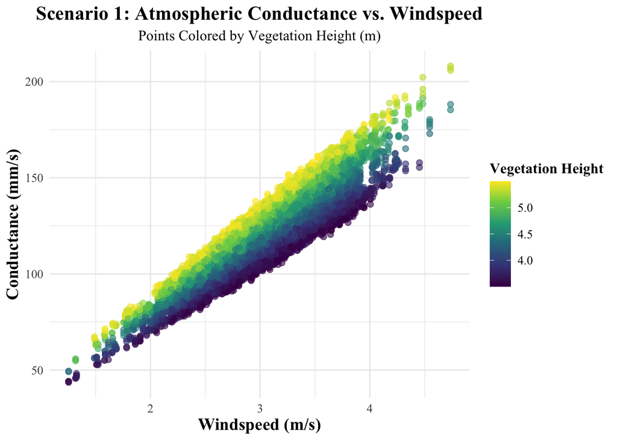

```r
#plot conductance vs. windspeed, color by second-most influential parameter
ggplot(X_transformed1, aes(x = v, y = Ca, color = .data[["h"]])) +
  geom_point(alpha = 0.6, size = 2) +
  scale_color_viridis_c(name = "Vegetation Height", option = "D") +
  labs(title = "Scenario 1: Atmospheric Conductance vs. Windspeed",
       subtitle = paste("Points Colored by Vegetation Height", "(m)"),
       x = "Windspeed (m/s)",
       y = "Conductance (mm/s)") +
  theme_minimal() +
  theme(text = element_text(family = "Times New Roman"),
        plot.title = element_text(face = "bold", size = 16, hjust = 0.5),
        plot.subtitle = element_text(size = 12, hjust = 0.5),
        axis.title = element_text(face = "bold", size = 14),
        axis.text = element_text(size = 10),
        legend.title = element_text(face = "bold", size = 12),
        legend.text = element_text(size = 10))
```

### 2. Scenario Two

[figure not shown]

```r
#plot conductance vs. windspeed, color by vegetation height
ggplot(X_transformed2, aes(x = v, y = Ca, color = .data[["h"]])) +
  geom_point(alpha = 0.6, size = 2) +
  scale_color_viridis_c(name = "Vegetation Height", option = "D") +
  labs(title = "Scenario 1: Atmospheric Conductance vs. Windspeed",
       subtitle = paste("Points Colored by Vegetation Height", "(m)"),
       x = "Windspeed (m/s)",
       y = "Conductance (mm/s)") +
  theme_minimal() +
  theme(text = element_text(family = "Times New Roman"),
        plot.title = element_text(face = "bold", size = 16, hjust = 0.5),
        plot.subtitle = element_text(size = 12, hjust = 0.5),
        axis.title = element_text(face = "bold", size = 14),
        axis.text = element_text(size = 10),
        legend.title = element_text(face = "bold", size = 12),
        legend.text = element_text(size = 10))
```

From these plots it is readily apparent that there is a strong relationship between windspeed and atmospheric conductance for both scenarios. However, based on the distributions of color points, we can also see that there is a relationship between vegetation height and conductance in scenario one, but this is not a driving parameter in scenario two.

# V. References

Saltelli, Andrea, and Paola Annoni. 2010. “How to Avoid a Perfunctory Sensitivity Analysis.” *Environmental Modelling & Software* 25 (12): 1508–17. https://doi.org/10.1016/j.envsoft.2010.04.012.